# 第11回 閉店から逆算する

経済プログラミング特論II

第11回・開店 19 日目

閉店から逆算する

後ろから決めると、前が決まる

経済プログラミング特論II

第11回・開店 19 日目 — Topic01

期待値

売上に買う割合を掛けて、最後の 1 人の値段を決める

## うちの店と 4 段の店長

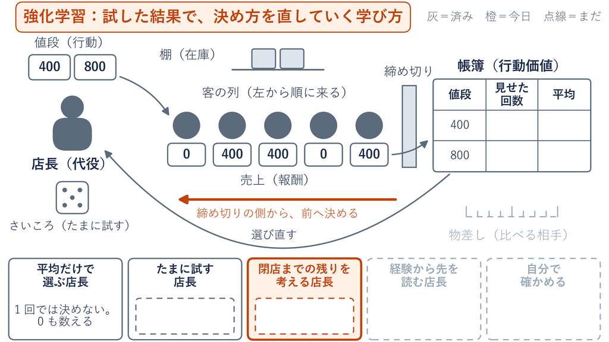

## 前の回の合言葉

前の回の合言葉：ふだんは一番、たまにわざと

前の回の最後に封印した場面  
1 点ものの品が残り 1 個・残り 2 人  
1 人目に見せる値段は？ **①** 400 円 **②** 800 円 **③** どちらでも同じ

## 前の日の場面と今日の相談

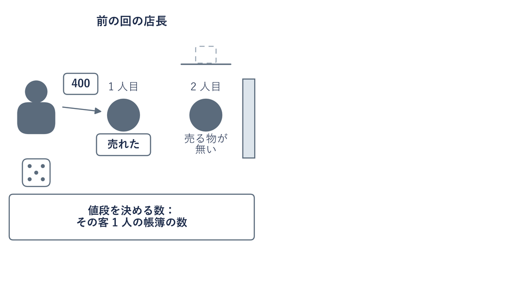

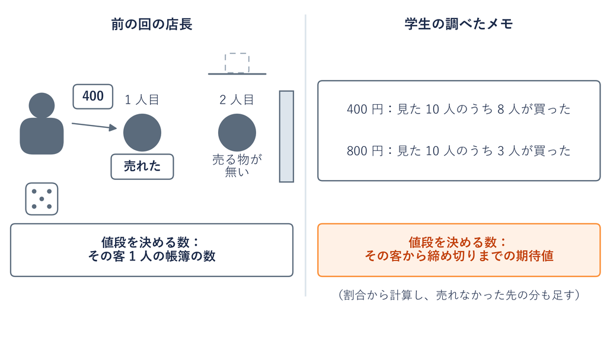

## 今日の道のり

1

最後の 1 人

実習：写経 期待値の 4 行

実習：実行 1 万回のやり直し

演習 1 割合を 0.5 に

2

残り 2 人

実習：写経 後ろからの 3 STEP

演習 2 ずっと 800 円

3

全部の状態

実習：写経 表から 1 マス

実習：実行 12 状態の表

演習 3 (3, 1) の手計算

4

毎日の運

実習：写経 表が下の日を数える

演習 4 相手の取り替え

**今日の相談**：割合が当てられたら、試さずに決められるか

## 最後の 1 人に見せる値段

いまの状態（残りの人数, 在庫）

(1, 1)

**状態**：(残りの人数, 在庫) の組。いまは残り 1 人・在庫 1 の (1, 1)  
1 点ものの品が残り 1 個で、締め切り前の最後の 1 人

**割合**：学生が調べた割合。400 円なら 10 人に 8 人、800 円なら 10 人に 3 人が買う

**仮定**：締め切りの後に売れ残った品は、もう売れない（0 円）

この店なら、最後の 1 人に見せる値段は？  
**①** 400 円 **②** 800 円 **③** どちらでも同じ

動画を止めて、①〜③から1つ選んで、少し考えてから再生

## 割合どおりの 10 人

いまの状態（残りの人数, 在庫）

(1, 1)

最後の 1 人の場面が 10 回来たとする。割合どおりに買う 10 人を並べる

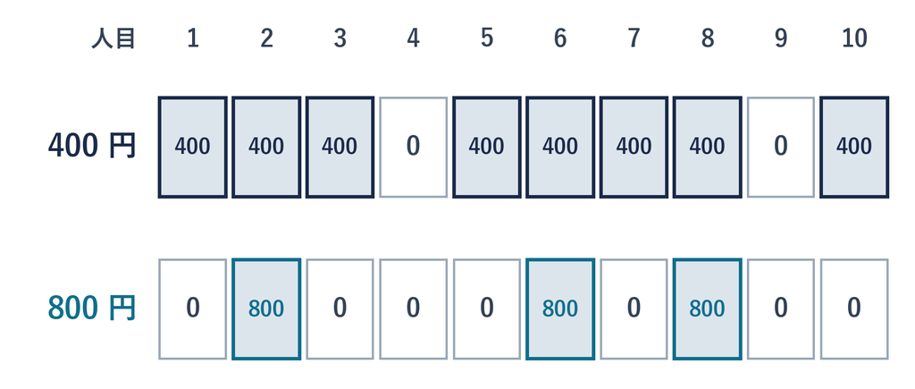

**400 円**：8 人 × 400 ＝ 3200 円。10 人でならすと 1 人あたり 320 円

**800 円**：3 人 × 800 ＝ 2400 円。10 人でならすと 1 人あたり 240 円

最後の 1 人の答えは ①。ならした 1 人あたりで、400 円が 80 円多い

前に出てきた帳簿と同じ数え方（0 も数える）。違うのは、割合どおりの 10 人で数えること

## 期待値

**売れたときの売上に、買う割合を掛けたもの**

前に出てきた期待値を、割合の式で計算する（あとで残りの人のぶんを足すため）

**期待値**起こりうる売上それぞれに、その起こる割合を掛けて足した値

期待値 ＝売れたときの売上 × 買う割合

＋ 売れないときの売上 × 買わない割合

400 円

$400 \times 0.8 + 0 \times 0.2$

$= 320$

10 人の 3200 ÷ 10 と同じ

800 円

$800 \times 0.3 + 0 \times 0.7$

$= 240$

10 人の 2400 ÷ 10 と同じ

**言い換え**：期待値は、ならした売上。400 円の期待値は 320 円

## 最後の 1 人の 2 本の枝

いまの状態（残りの人数, 在庫）

(1, 1)

[figure not shown]

## 最後の 1 人の 1 万回のやり直し

今度は同じ最後の 1 人を、seed 42 で何度もやり直す

[figure not shown]

10 回では 800 円が上に見える。1 万回で 320 円と 240 円の近くに戻る

前の回の店長：帳簿の数（10 回では 800 円が上）／期待値：割合から試さずに 320 対 240

## 使える場面：1 点ものの値付け

✕ 売れたらいくら

800 円 ＞ 400 円  
売れたときの額だけ  
見ると 800 円

○ ならしていくら

240 円 ＜ 320 円  
買う割合を掛けると 400 円

フリマアプリで 1 点ものを出品するときも、  
売れたときの額に買う割合を掛けて比べる

## 期待値の写経

```python
PRICE = {400: 0.8, 800: 0.3}          # 値段 → 買う割合
for price, p in PRICE.items():        # 400 円と 800 円を順に
    expect = price * p + 0 * (1 - p)  # 売れたら値段、売れなければ 0 円
    print(price, "円の期待値:", expect)
```

| 行 | 部品 | 中身 |
| --- | --- | --- |
| 1 | **① 値段と割合の表** | 値段で調べると、買う割合が出る表（辞書）。400 円なら 0.8 |
| 2 | **② 1 つずつ** | price に値段、p にその割合が順に入る |
| 3 | **③ 期待値** | p.9 の式そのもの。(1 − p)：買わない割合（売れなければ 0 円） |
| 4 | **④ 表示** | 値段と期待値を 1 行に出す |

※ `PRICE.items()`：表から（値段, 割合）の組を 1 つずつ取り出す

## 期待値の写経と実行

先に：ノート先頭の記録のセルを **▶**

1. **＋ コード**で  
   セルを足す
2. p.13 のコードを写す
3. **▶** か **Shift + Enter** で実行  
   （Mac は Shift + return）
4. 1 万回のセルは  
   写さずに **▶** だけ

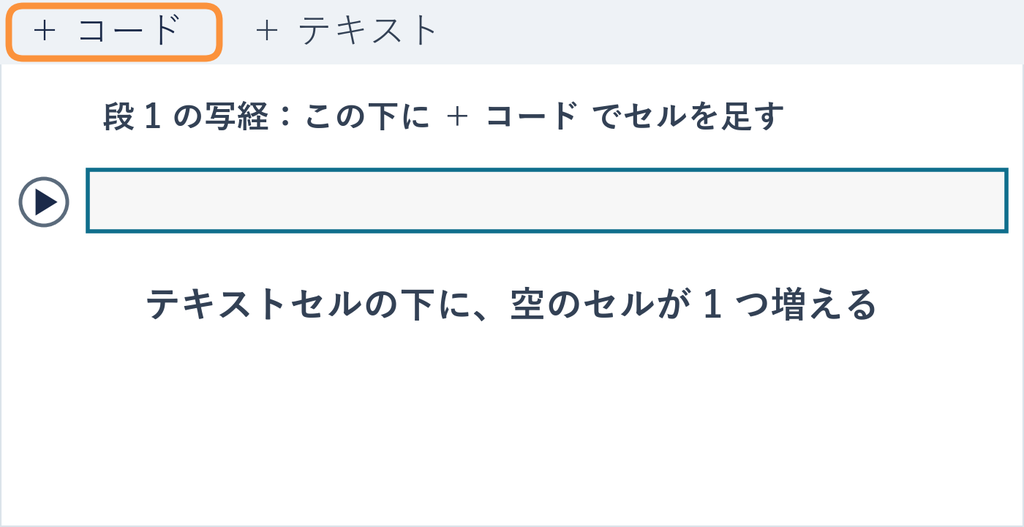

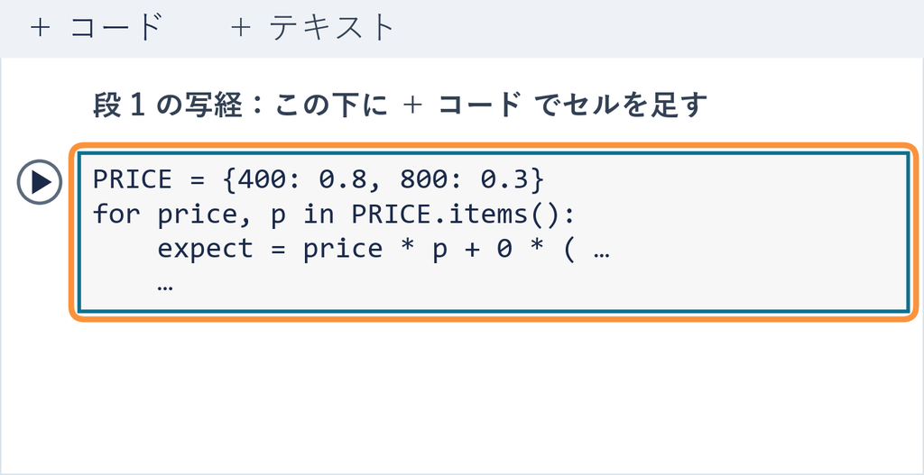

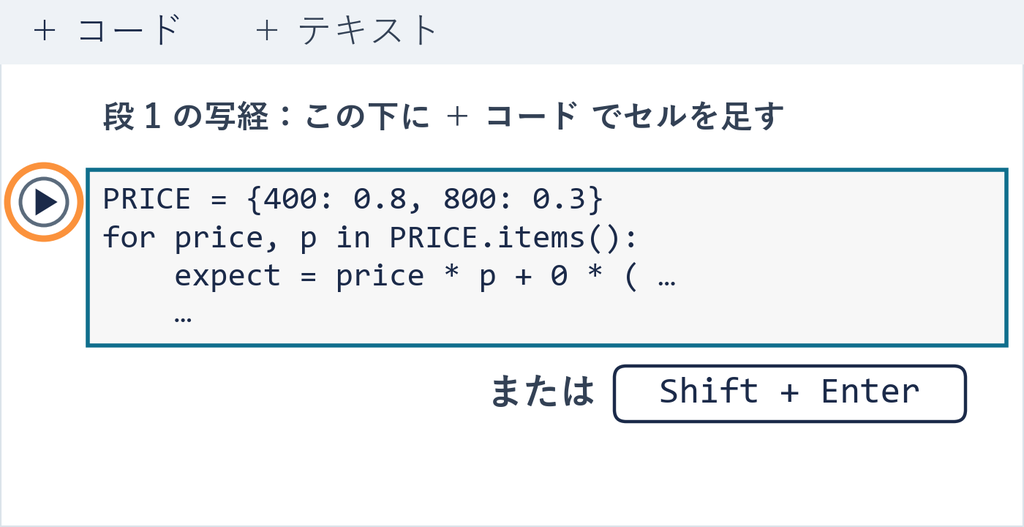

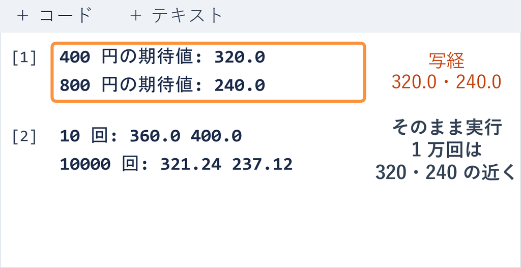

⏸ PAUSE 動画を止めて $5$ 分。2 つのセルの出力が出たら再生に戻る

## 演習1 800 円の割合

演習 1

800 円で買う人が 10 人に 5 人なら、最後の 1 人の答えは変わるか

```python
PRICE = {400: 0.8, 800: 0.3}          # ← ここを書き換える
for price, p in PRICE.items():        # 400 円と 800 円を順に
    expect = price * p + 0 * (1 - p)  # 売れたら値段、売れなければ 0 円
    print(price, "円の期待値:", expect)
```

1. **書き換える**：**＋ コード**で足したセルに写経を写し  
   1 行目の 0.3 を 0.5 に
2. **予想する**：最後の 1 人に見せる値段は（400 円のまま／800 円に変わる）
3. **終わり**：実行して、答えと 800 円の期待値を答え欄に書く

⏸ PAUSE 動画を止めて $5$ 分。2 行が出たら再生に戻る

## 演習1の答え

[figure not shown]

- **答え**：800 円に変わる。800 円の期待値 400 円は 320 円より多い
- **境目**：10 人に 4 人なら 320 円で同じ。同じなら 400 円のまま

割合が変われば、答えが変わる

※ 配布のデモ（lecture11_dp_demo.html）の「最後の 1 人」で、2 つの値段の計算を自分でも出せる

## まとめ

疑問 この店なら、最後の 1 人に見せる値段は？

回答 この店なら、安いほうの値段  
売れる割合を掛けた期待値で比べ、  
大きいほうを見せる

経済プログラミング特論II

第11回・開店 19 日目 — Topic02

後ろ向き帰納法

売れなかった先の期待値を、今に足す

## 前の日の場面をもう一度

いまの状態（残りの人数, 在庫）

(2, 1)

**これまで**：最後の 1 人なら 400 円

**前の日**：1 人目に 400 円で売れて、2 人目に売る品が無かった

**問い**：最後の 1 人の答えを、そのまま残り 2 人に使ってよいか

**前の回に封印した予想を、ここで開けます**  
1 点ものの品が残り 1 個、残り 2 人がページを開く  
1 人目に見せる値段は？  
**①** 400 円 **②** 800 円 **③** どちらでも同じ

動画を止めて、①〜③から 1 つ選び、理由も考えてから再生

## 2 人目の期待値

いまの状態（残りの人数, 在庫）

(2, 1)

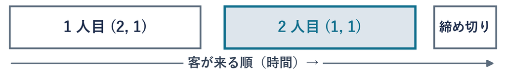

[figure not shown]

締め切りに近い 2 人目 (1, 1) から。400 円で期待値 320 円

## 1 人目に 800 円を見せる枝

いまの状態（残りの人数, 在庫）

(2, 1)

[figure not shown]

売れれば今 800 円。売れないと品が残って (1, 1) へ。□ に入るのは、  
そのあとの客から得る期待値

```
v800 = 0.3 * 800 + 0.7 * □
v400 = 0.8 * 400 + 0.2 * □
print(v800, v400)
```

⏸ PAUSE 動画を止めて、  
ノートの段 2 の確かめのセルの □ に 0 を入れて ▶ を押し、  
320 を入れて ▶ を押す。2 組の数が出たら再生

## 売れなかった枝は 0 円か

いまの状態（残りの人数, 在庫）

(2, 1)

□＝0：売れなかった枝は 0 円

800 円は  
3 × 800 ＋ 7 × 0 ＝ 2400  
10 回でならして 240 円  
400 円を見せたときの  
320 円より低い

○ □＝320：その先に 320 円

売れなかった 7 回にも  
品が残り、もう 1 人が来る  
その先は 320 円

売れなかった枝にも、先の期待値が残る

## 同じ場面が 10 回来たら

いまの状態（残りの人数, 在庫）

(2, 1)

同じ場面が 10 回来たとする。どの回も 1 人目に同じ値段を見せる

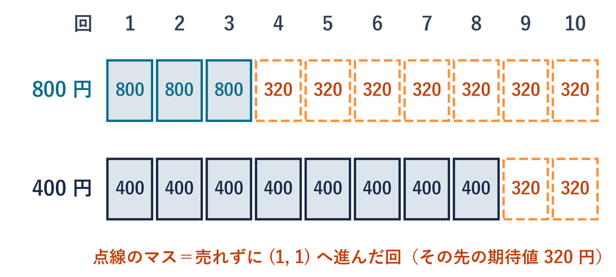

**800 円**：3 × 800 ＋ 7 × 320 ＝ 4640 円。10 回でならすと 464 円

**400 円**：同じ形で数えると 384 円

封印した予想の答えは ②。800 円のほうが、ならして 80 円多い

確かめのセル：□＝0 なら 240 と 320（400 円が上）／□＝320 なら 464 と 384（800 円が上）

## 後ろから決める

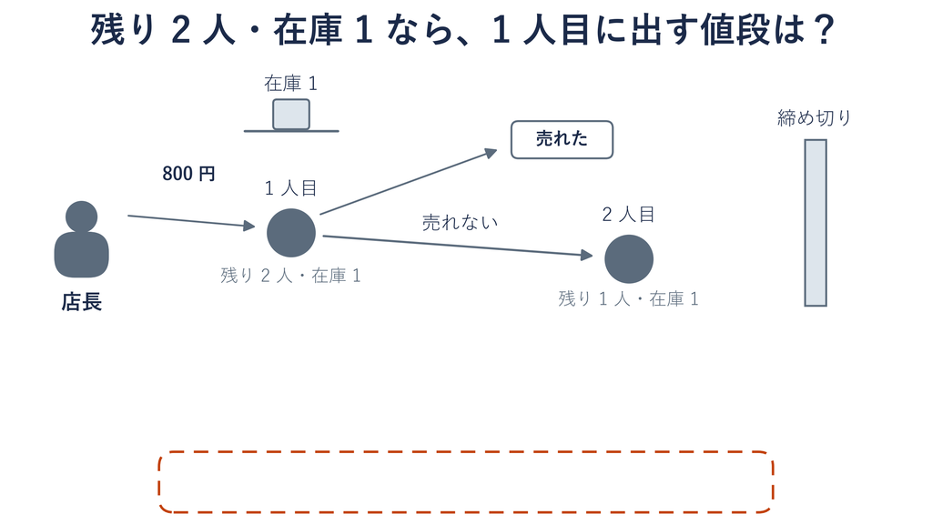

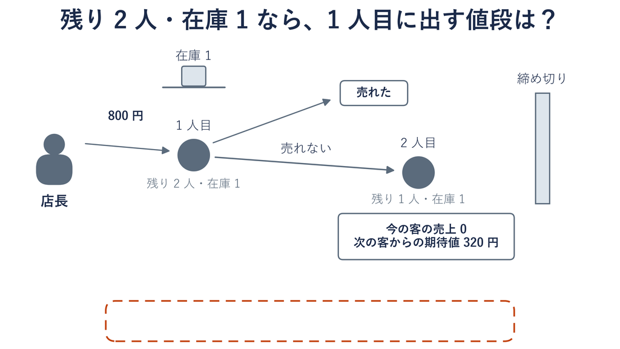

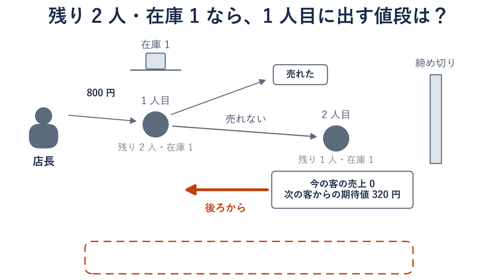

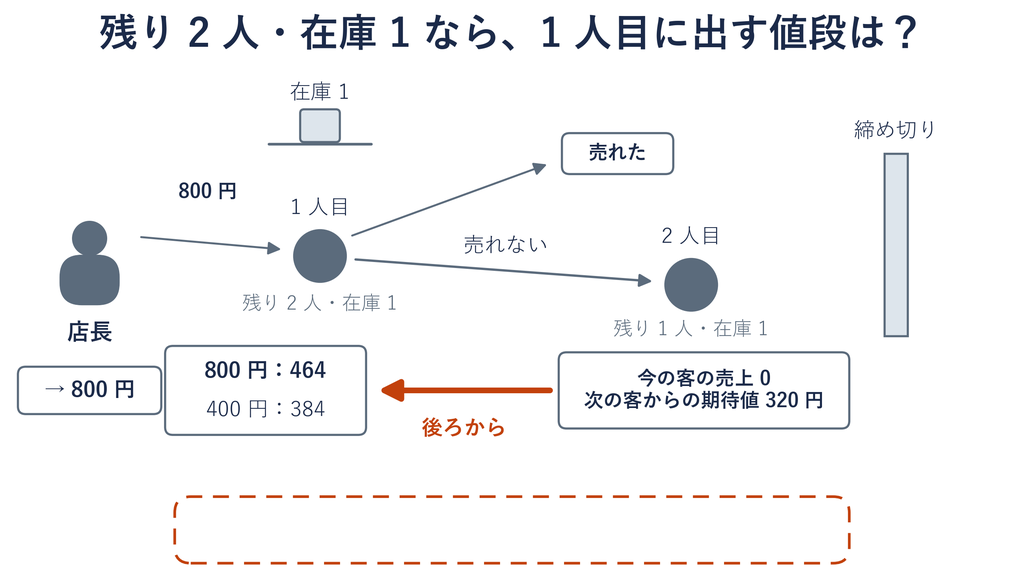

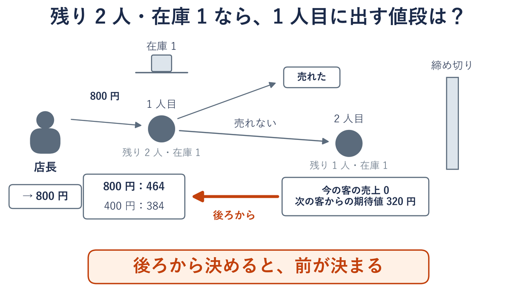

## 後ろ向き帰納法

いまの状態（残りの人数, 在庫）

(2, 1)

**後ろから決めると、前が決まる**

定義

**後ろ向き帰納法**閉店の側（締め切りの側）から、先の期待値を使って  
前の値段を決める手順

[figure not shown]

（締め切りの側から決める考え方。ゲーム理論では 逆向き帰納法）

## 前の日の場面の 1 万回のやり直し

いまの状態（残りの人数, 在庫）

(2, 1)

この場面を、計算機の中で 1 万回動かす  
3 つの値段の見せ方に、同じ客の並びを使う

[figure not shown]

1 万回では 800 円 → 400 円がいちばん上。▼の 10 回だけでは読み違える

## デモ 後ろから決める：残り 2 人・在庫 1

数の話

期待値 ＝ 割合 × 値段 ＋（1 − 割合）× 2 人目の期待値

- **何を見るか**：売れなかった枝の先に置かれる、2 人目の期待値
- **図の意味**：左＝1 人目・右上＝売れた枝・右下＝売れなかった先
- **操作**：1 人目の値段を選ぶ・売れなければ 2 人目の値段を選ぶ

ミッション 1 人目を 400 円にして、2 人目を切り替える。  
期待値は 384 円のままか

※ 次のスライドへ進むときは、デモの枠の外を一度クリックしてから ← → キーを押す

[interactive chart not shown]

## 後ろからの 3 STEP の写経

```python
last = max(400 * PRICE[400], 800 * PRICE[800])     # STEP 1 最後の 1 人
v800 = PRICE[800] * 800 + (1 - PRICE[800]) * last  # STEP 2 1 人目に 800 円
v400 = PRICE[400] * 400 + (1 - PRICE[400]) * last  # STEP 2 1 人目に 400 円
print(last, v800, v400)                            # STEP 3 大きいほうを選ぶ
```

| 行 | 部品 | 中身 |
| --- | --- | --- |
| 1 | **STEP 1：2 人目** | max＝大きいほう。最後の 1 人の期待値 320.0 |
| 2-3 | **STEP 2：1 人目** | 売れた枝 ＋ 買わない割合 × last |
| 4 | **STEP 3：選ぶ** | 2 つ目と 3 つ目の大きいほう |

※ 計算の向き ←：先に 2 人目の期待値 last（1 行目）、その答えで 1 人目（2〜3 行目）  
※ `PRICE` は p.13 で作り、段 2 の準備のセルで元の割合に戻した表  
`PRICE[800]`：表から 800 円の割合 0.3 を引く

**①** 【そのまま実行】の段 2 の準備のセルを先に **▶** **②** **＋ コード**でセルを足し、上の 4 行を写して実行。  
2 つ目と 3 つ目（464.0 と 384.0）を比べる

⏸ PAUSE 止めて Colab で写して実行（目安 5 分）。1 行の出力が出たら再生に戻る

## 演習2 ずっと 800 円

演習 2

2 人目も 800 円のままなら、1 人目に 800 円の期待値はいくらか

```python
last = max(400 * PRICE[400], 800 * PRICE[800])     # ← ここを書き換える
v800 = PRICE[800] * 800 + (1 - PRICE[800]) * last  # STEP 2 1 人目に 800 円
v400 = PRICE[400] * 400 + (1 - PRICE[400]) * last  # STEP 2 1 人目に 400 円
print(last, v800, v400)                            # STEP 3 大きいほうを選ぶ
```

1. **書き換える**：足したセルに写して、1 行目を `last = 800 * PRICE[800]`（2 人目も 800 円）に
2. **確かめる**：p.26 の「ずっと 800 円」（1 万回で 404.0 円）の近くになるか
3. **終わり**：実行して、2 つ目の数が出たら答え欄に書く

⏸ PAUSE 動画を止めて $5$ 分。2 つ目の数が出たら再生に戻る

## 演習2の答え

いまの状態（残りの人数, 在庫）

(2, 1)

**2 人目**：800 円のままなら、先の期待値は 800 × 0.3 ＝ 240 円

**1 人目**：3 × 800 ＋ 7 × 240 ＝ 4080 円。10 回でならすと 408 円

- **答え**：408 円。1 万回の 404.0 円の近くで、464 円には届かない
- **理由**：2 人目の値段の見せ方が違う。元の 464 円は、  
  売れなければ 2 人目に 400 円を見せる場合

後ろ向き帰納法の答えは「ずっと 800 円」ではなく  
「800 円、売れなければ 400 円」

## まとめ

疑問 残り 2 人・在庫 1 なら、1 人目に見せる値段は？

回答 高いほうの値段  
売れなかった枝の先にも、2 人目の期待値が残る

経済プログラミング特論II

第11回・開店 19 日目 — Topic03

価値関数と方策

答えは値段 1 つでなく、状態ごとの表になる

## 残り 2 人・在庫 2 の 1 人目

いまの状態（残りの人数, 在庫）

(2, 2)

(2, 1) との違いは、在庫が 1 → 2 になっただけ（どちらも残り 2 人）  
そこから全部の状態の表へ広げる（学生が作った表・確かめた 3 マスだけ記入）

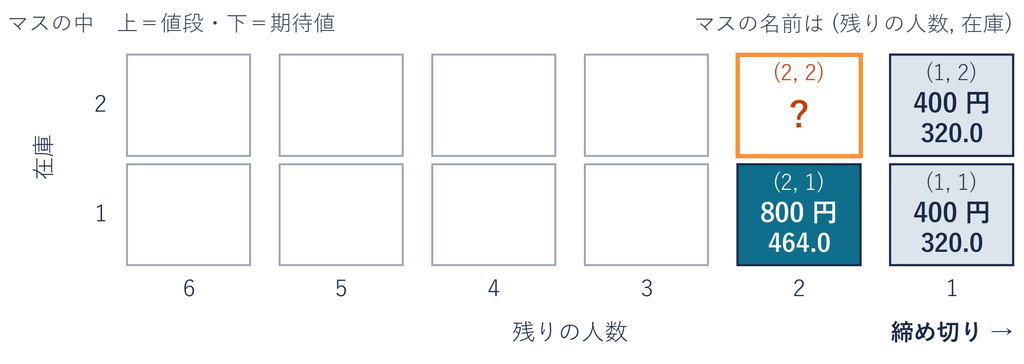

この店で、残り 2 人・在庫 2 個なら、1 人目に見せる値段は？  
**①** 400 円 **②** 800 円 **③** どちらでも同じ

動画を止めて、①〜③から 1 つ選び、理由も考えてから再生

## 締め切りの側から埋める 4 マス

いまの状態（残りの人数, 在庫）

(2, 2)

[figure not shown]

**残り 1 人の列**：(1, 1)・(1, 2) はどちらも 400 円で 320 円（最後の 1 人に売れるのは 1 個だけ）

**(2, 1)**：800 円で 464 円（売れなかった枝の先の期待値も足した）

**(2, 2)**：品が 2 個なら？ 次のページで数える

## (2, 2) の期待値

いまの状態（残りの人数, 在庫）

(2, 2)

[figure not shown]

**400 円**：10 回なら 8 × (400 ＋ 320) ＋ 2 × 320 ＝ 6400 円。1 回あたり 640 円

**800 円**：同じ形で数えると 560 円

入口の答えは ①。売れても売れなくても、先は同じ 320 円なので、  
在庫 2 なら 400 円（在庫 1 とは逆）

## 1 マスが見る 2 マス

いまの状態（残りの人数, 在庫）

(2, 2)

[figure not shown]

1 マスの計算に、右隣の列の 2 マスが要る。  
だから締め切りの側（右）から埋める

## 12 状態の期待値の表

いまの状態（残りの人数, 在庫）

(6, 2)

今度は 12 状態（残りの人数 1〜6 × 在庫 1〜2）を、同じ手順で全部埋める

**価値**：表の下の数。その状態からの期待値を、価値と呼ぶ

[figure not shown]

**埋め方**：右端の残り 1 人の列から左へ 1 列ずつ。どのマスも右隣の列の 2 マスを使う

**(6, 2)**：店の出発点の価値は 1231.2 円。期待値なので小数が出る

## 12 状態の値段の表

いまの状態（残りの人数, 在庫）

(6, 2)

**方策**：状態ごとに見せるべき値段の表（値段の表）

[figure not shown]

**読み方**：左（開店に近い）ほど 800 円。右端の締め切りの列は、先が 0 円なので 400 円

**在庫 1**：800 円で外れても、売れなかった先に期待値が残る（(2, 1) は先が 320 円で 800 円）

**在庫 2**：売れた先と売れなかった先の差で決まる。(2, 2) は先がどちらも 320 円で 400 円

**使い方**：(6, 2) から始め、売れれば (5, 1) の、売れなければ (5, 2) の値段を引く

## 価値関数と方策

**価値はその状態からの期待値、方策は状態ごとの値段の表**

**価値関数**各状態に、その状態の価値を対応させたもの  
（ここでは 12 状態の期待値の表）

**方策**各状態に、そこで見せるべき値段を対応させた決まり  
（ここでは 12 状態の値段の表）

**今回は**：(2, 1) の価値は 464 円で 800 円・(2, 2) の価値は 640 円で 400 円

**値段 1 つなら**：残り 2 人の 800 円を (2, 2) にも使うと 560 円

（表を締め切りの側から 1 列ずつ埋める計算は、動的計画法と呼ばれる）

## デモ 表のマスが見る 2 マス

数の話

1 マスの価値 ＝ 大きいほう（400 円から, 800 円から）

- **何を見るか**：押したマスと、そのマスが見る右の 2 マス（売れたら 1 つ  
  右・在庫 1 つ下のマス、売れなければ 1 つ右の同じ在庫のマス）
- **図の意味**：上＝12 マスの表・下＝押したマスの計算
- **操作**：マスを押す（点線の 0 は締め切りと売り切れ）

ミッション (3, 1) を押して、  
そのマスが見る右の 2 マスを見つける

※ 次のスライドへ進むときは、デモの枠の外を一度クリックしてから ← → キーを押す

[interactive chart not shown]

## 表から 1 マスの写経

```python
sold = value[(1, 1)]                      # 売れた先 (1, 1) の価値
unsold = value[(1, 2)]                    # 売れなかった先 (1, 2) の価値
v400 = 0.8 * (400 + sold) + 0.2 * unsold  # 1 人目に 400 円
v800 = 0.3 * (800 + sold) + 0.7 * unsold  # 1 人目に 800 円
print(v400, v800)                         # 大きいほうを選ぶ
```

| 行 | 部品 | 中身 |
| --- | --- | --- |
| 1-2 | **① 表を引く** | `value[(1, 1)]`：状態の組 (1, 1) で、表からその価値を引く |
| 3-4 | **② 2 つの値段** | 売れた枝と売れなかった枝の先に、割合を掛けて足す |
| 5 | **③ 比べる** | 2 つの数を表示。大きいほうの値段を選ぶ |

※ `value` は【そのまま実行】のセル（12 状態の表）で作った価値の表のまま

**STEP 1** 【そのまま実行】の 12 状態の表のセルを先に **▶** **STEP 2** **＋ コード**でセルを足し、  
上の 5 行を写して実行。640.0 と 560.0 を見比べる

⏸ PAUSE 止めて Colab で写して実行（目安 5 分）。640.0 560.0 が出たら再生に戻る

## 演習3 (3, 1) の手計算

いまの状態（残りの人数, 在庫）

(3, 1)

演習 3

(3, 1) の価値を、(2, 1) の 464 円から手で出す

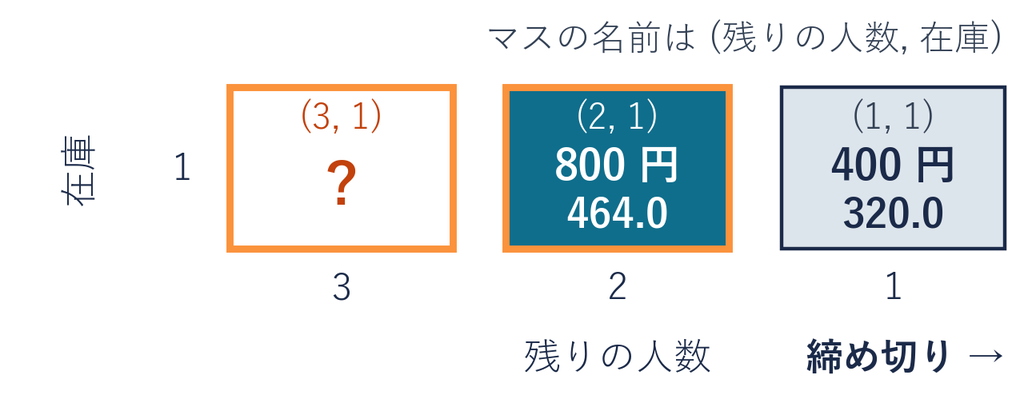

1. **書く場所**：小課題ノートの段 3 の演習の答え欄
2. **書くこと**：800 円と 400 円の、10 回で数えた合計と 1 回あたりの額・見せる値段
3. **手がかり**：買う割合は 400 円が 10 回に 8 回、800 円が 10 回に 3 回
4. **終わり**：【そのまま実行】の出力の (3, 1) の行と照らせたら

⏸ PAUSE 動画を止めて $5$ 分。2 つの額が書けたら再生に戻る

## 演習3の答え

いまの状態（残りの人数, 在庫）

(3, 1)

**800 円**：3 × 800 ＋ 7 × 464 ＝ 5648 円。10 回でならすと 564.8 円

**400 円**：8 × 400 ＋ 2 × 464 ＝ 4128 円。10 回でならすと 412.8 円

- **答え**：800 円。【そのまま実行】の出力の (3, 1) 800 564.8 と同じ
- **見方**：売れた 3 回は在庫 0 で受付終了。  
  売れなかった 7 回は (2, 1) の 464 円へ

コードの 1 行は、手で数えた 1 マスと同じ計算

## まとめ

疑問 残り 2 人・在庫 2 なら、  
1 人目に見せる値段は？

回答 安いほうの値段。在庫 1 とは答えが逆  
答えは値段 1 つでなく、  
状態ごとの値段の表になる

経済プログラミング特論II

第11回・開店 19 日目 — Topic04

最適性

表は平均でいちばん売れるが、毎日売上が上とは限らない

## 表どおりに見せる店長の売上が下になる日

**表どおりに見せる店長は、本当に毎日売上が上なのか**

店長＝計算機の中に作る、決まった見せ方で値段を見せるプログラム

- **比べる相手**：ずっと 400 円の店長
- **並べ方**：同じ客で、1000 日

表どおりに見せる店長の売上が下になる日は、1000 日のうち何日か  
**写経のセルで、自分で数えて確かめる**

## 2 人の店長の 1 日（seed 5）

いまの状態（残りの人数, 在庫）

(6, 2)

(5, 2)

(4, 2)・(3, 2)

(2, 2)

(1, 1)

学生が計算機の中で動かした 1 日。同じ客（seed 5）で、2 人の店長を客 1 人ずつ並べる

| 客 | 表どおり：状態 | 値段 | 買った | ずっと 400 円：状態 | 値段 | 買った |
| --- | --- | --- | --- | --- | --- | --- |
| 1 | (6, 2) | 800 | × | (6, 2) | 400 | ○ |
| 2 | (5, 2) | 800 | × | (5, 1) | 400 | ○ |
| 3・4 | (4, 2)・(3, 2) | 800 | ×・× | 売り切れ | — | — |
| 5 | (2, 2) | 400 | ○ | 売り切れ | — | — |
| 6 | (1, 1) | 400 | × | 売り切れ | — | — |
| **売上** |  |  | **400 円** |  |  | **800 円** |

この日は、表どおりに見せる店長の売上が下だった。  
表の引き方は合っていても、運で下になる日がある

## 最適性

**たくさんの日の平均でいちばん売れること**

**最適**1 日の売上の期待値が  
いちばん大きい方策であること

- **言っていること**：仮定した店（4 つの仮定は p.53）で期待値がいちばん大きい。  
  日数を増やすと平均はその期待値に近づく
- **言っていないこと**：毎日売上が上。限られた日数なら必ず上

売上が下になる日は 0 日ではなく、少しある。最適は平均の話で、  
毎日の売上の上下の話ではない

## 1000 日の売上の差

今度は seed 0〜999 の 1000 日。同じ日は同じ客で、2 人の店長の売上の差を数える

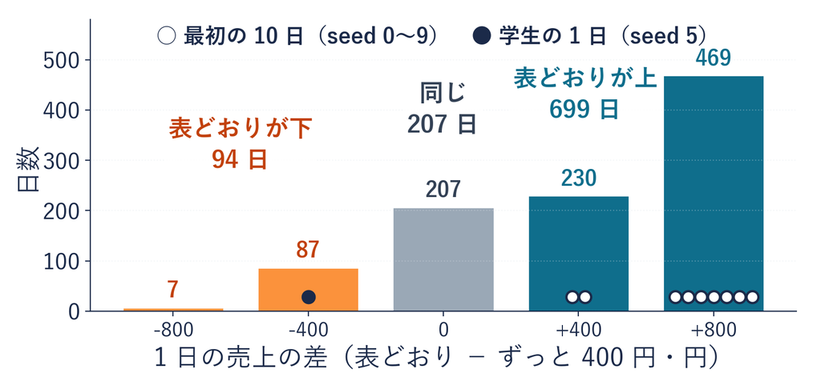

○ 最初の 10 日（seed 0〜9）は 10 日のうち 9 日が上、1 日が下。  
下だった 1 日が、学生の動かした seed 5 の日

表どおりが下の日は 94 日。1000 日の平均は 1226.4 円 対 799.6 円

## 店長ごとの期待値

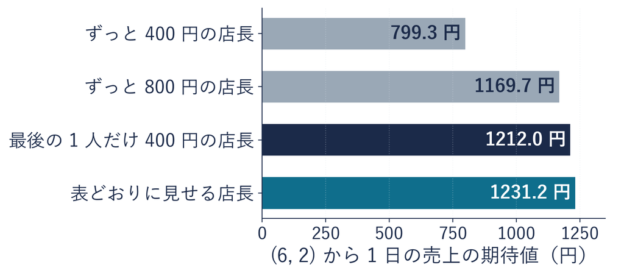

表どおりに見せる店長がいちばん上。割合が分かる店では、  
これより上の見せ方は無い

ただし、最後の 1 人だけ 400 円の店長とは約 19 円の差

最後の 1 人だけ 400 円の店長と表の違いは (2, 2) の 1 マスだけ（800 円 対 400 円）

## この表が最適である条件

仮定

**割合**分かっていて変わらない（400 円は 0.8・800 円は 0.3）

**次の場面**今の（残りの人数, 在庫）と値段だけで決まる  
前の客の様子で、後の客の買い方は変わらない

**品と締め切り**品は作り足さない。締め切りの後は 0 円

**目当て**増やしたいのは 1 日の売上の期待値

割合が変われば、表も変わる  
（演習 1：800 円が 10 人に 5 人なら、最後の 1 人の答えが変わった）

自分で値段を決めるときも、表と一緒に何を仮定したかを書く。  
運の悪い 1 日だけで、表を捨てない

## 表が下の日を数える写経

```python
lose = 0                                  # 表が下の日の数
for seed in range(1000):                  # 1000 日
    if one_day(by_table, seed) < one_day(other, seed):
        lose += 1                         # 下なら 1 足す
print("表が下の日:", lose)
```

| 行 | 部品 | 中身 |
| --- | --- | --- |
| 1 | **① 数える箱** | `lose` を 0 から始める |
| 2 | **② 1000 日** | seed 0〜999 の 1000 日。同じ seed の日は同じ客 |
| 3-4 | **③ 店長を渡す** | `one_day(by_table, seed)`：店長の名前を渡すと、 その店長で 1 日を動かす。相手より下なら 1 足す |
| 5 | **④ 表示** | 表が下の日の数 |

**STEP 1** 【そのまま実行】の段 4 の準備のセル（one_day と 3 人の店長）を先に **▶** **STEP 2** **＋ コード**でセルを足し、  
上の 5 行を写して実行。表が下の日: 94 を探す

⏸ PAUSE 止めて Colab で写して実行（目安 5 分）。表が下の日の数が出たら再生に戻る

## 演習4 相手の取り替え

演習 4

相手を「最後の 1 人だけ 400 円の店長」  
にすると、表が下の日は何日か

```python
for seed in range(1000):                  # 1000 日
    if one_day(by_table, seed) < one_day(other, seed):
        lose += 1                         # 下なら 1 足す
```

1. **書き換える**：**＋ コード**で足したセルに写経の枚の 5 行を写し  
   `if` の行の `other` を `last400` に（1 か所）
2. **手がかり**：`last400` は最後の 1 人だけ 400 円の店長（準備のセルにある）
3. **予想する**：下の日は 94 日より（多い／少ない）
4. **終わり**：実行して、表が下の日の数が出たら答え欄に書く

⏸ PAUSE 動画を止めて $5$ 分。表が下の日の数が出たら再生に戻る

## 演習4の答え

**出力**：表が下の日: 78（同じ日 807・上の日 115 は段 4 の図と日数のセルの出力）

**平均**：1226.4 円 対 1211.6 円（差 約 15 円）

[figure not shown]

- **答え**：少ない。表が下の日は 78 日
- **わけ**：同じ値段を見せる状態が多いので、同じ日が 807 日といちばん多い

強い単純な店長とは、ほとんどの日が同じ。それでも平均では表どおりが上

## まとめ

疑問 表どおりに見せる店長は、本当に毎日売上が上なのか

回答 毎日は上にならない  
それでも、たくさんの日の平均ではいちばん上

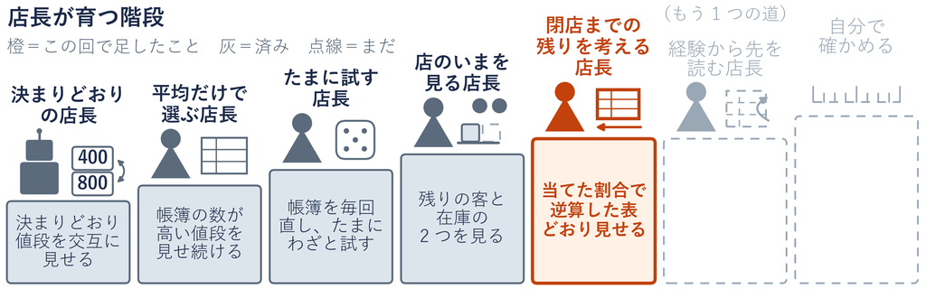

## 今日の 4 つの疑問と回答

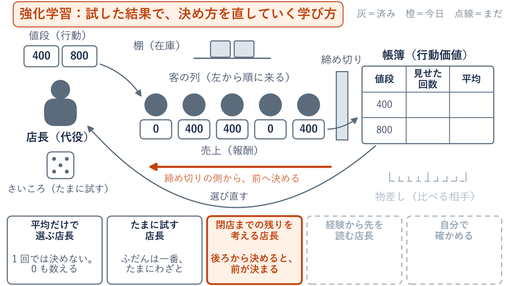

|  | 疑問 | 回答 |
| --- | --- | --- |
| T1 | この店なら、 最後の 1 人に見せる値段は？ | 安いほうの値段。 売れる割合を掛けた期待値で比べ、 大きいほうを見せる |
| T2 | 残り 2 人・在庫 1 なら、 1 人目に見せる値段は？ | 高いほうの値段。売れなかった枝の先にも、 2 人目の期待値が残る |
| T3 | 残り 2 人・在庫 2 なら、 1 人目に見せる値段は？ | 安いほうの値段。在庫 1 とは答えが逆。 答えは状態ごとの値段の表 |
| T4 | 表どおりに見せる店長は、 本当に毎日売上が上なのか | 毎日は上にならない。それでも、 たくさんの日の平均ではいちばん上 |

やること：演習 1〜4 の答え欄を書いて、いつもの手順で提出

**後ろから決めると、前が決まる**